# case 1

```python
import numpy as np
import pandas as pd
import matplotlib.pyplot as plt
import seaborn as sns
from sklearn.metrics import accuracy_score
from sklearn.model_selection import train_test_split
```

```python
df = pd.read_csv(r'C:\Users\huang\stout interview\loans_full_schema.csv')
```

## Description and Assumptions. Problem statement

This data set represents thousands of loans made through the Lending Club platform. Some loans are safer and some aren't. The data represents loans made and not loan applications. The dataset favors less risky.

Higher risk- high interest rate. low risk- low interest rate.

Problem statement- using data, create a model to predict the interest rate

```python
df.head(10)
```

|  | emp_title | emp_length | state | homeownership | annual_income | verified_income | debt_to_income | annual_income_joint | verification_income_joint | debt_to_income_joint | ... | sub_grade | issue_month | loan_status | initial_listing_status | disbursement_method | balance | paid_total | paid_principal | paid_interest | paid_late_fees |
| --- | --- | --- | --- | --- | --- | --- | --- | --- | --- | --- | --- | --- | --- | --- | --- | --- | --- | --- | --- | --- | --- |
| 0 | global config engineer | 3.0 | NJ | MORTGAGE | 90000.0 | Verified | 18.01 | NaN | NaN | NaN | ... | C3 | Mar-2018 | Current | whole | Cash | 27015.86 | 1999.33 | 984.14 | 1015.19 | 0.0 |
| 1 | warehouse office clerk | 10.0 | HI | RENT | 40000.0 | Not Verified | 5.04 | NaN | NaN | NaN | ... | C1 | Feb-2018 | Current | whole | Cash | 4651.37 | 499.12 | 348.63 | 150.49 | 0.0 |
| 2 | assembly | 3.0 | WI | RENT | 40000.0 | Source Verified | 21.15 | NaN | NaN | NaN | ... | D1 | Feb-2018 | Current | fractional | Cash | 1824.63 | 281.80 | 175.37 | 106.43 | 0.0 |
| 3 | customer service | 1.0 | PA | RENT | 30000.0 | Not Verified | 10.16 | NaN | NaN | NaN | ... | A3 | Jan-2018 | Current | whole | Cash | 18853.26 | 3312.89 | 2746.74 | 566.15 | 0.0 |
| 4 | security supervisor | 10.0 | CA | RENT | 35000.0 | Verified | 57.96 | 57000.0 | Verified | 37.66 | ... | C3 | Mar-2018 | Current | whole | Cash | 21430.15 | 2324.65 | 1569.85 | 754.80 | 0.0 |
| 5 | NaN | NaN | KY | OWN | 34000.0 | Not Verified | 6.46 | NaN | NaN | NaN | ... | A3 | Jan-2018 | Current | whole | Cash | 4256.71 | 873.13 | 743.29 | 129.84 | 0.0 |
| 6 | hr | 10.0 | MI | MORTGAGE | 35000.0 | Source Verified | 23.66 | 155000.0 | Not Verified | 13.12 | ... | C2 | Jan-2018 | Current | whole | Cash | 22560.00 | 2730.51 | 1440.00 | 1290.51 | 0.0 |
| 7 | police | 10.0 | AZ | MORTGAGE | 110000.0 | Source Verified | 16.19 | NaN | NaN | NaN | ... | B5 | Jan-2018 | Current | whole | Cash | 19005.39 | 1765.84 | 994.61 | 771.23 | 0.0 |
| 8 | parts | 10.0 | NV | MORTGAGE | 65000.0 | Source Verified | 36.48 | NaN | NaN | NaN | ... | C2 | Feb-2018 | Current | whole | Cash | 18156.66 | 2703.22 | 1843.34 | 859.88 | 0.0 |
| 9 | 4th person | 3.0 | IL | RENT | 30000.0 | Not Verified | 18.91 | NaN | NaN | NaN | ... | A3 | Mar-2018 | Current | fractional | Cash | 6077.13 | 391.15 | 322.87 | 68.28 | 0.0 |

10 rows × 55 columns

The categorical variables emp_title, state, homeownership, verified income, verification*income* joint, loan_purpose, application_type, grade, sub_grade, issue_month, loan_status, initial_listing_status, disbursement_method

Split into segments- joint or individual

Expectations on interest rate: emp-title : higher pay jobs( supervisors) -- lower interest rates emp-length: longer length -- lower interest rate state: none homeownership: mortgage (higher credit rating) / OWN -- lower interest

annual_income: higher pay -- lower interest verified income: verified -- lower interest debt_to_income: low -- lower interest

annual_income_joint: higher pay -- lower interest verif_income_joints: verified -- lower interest debt_to_income_joint: low -- lower interest

subgrade: A -- lower interest rate issue_month: none loan_status: none initial_listing_status: none disbursement method: none balance: high -- lower interest rate paid total: high --low interest paid principal: high --low interest paid rate: high --low interest paid rate: high --low interest paid_late_fee: low -- low interest

```python
df.info()
```

```
<class 'pandas.core.frame.DataFrame'>
RangeIndex: 10000 entries, 0 to 9999
Data columns (total 55 columns):
 #   Column                            Non-Null Count  Dtype
---  ------                            --------------  -----
 0   emp_title                         9167 non-null   object
 1   emp_length                        9183 non-null   float64
 2   state                             10000 non-null  object
 3   homeownership                     10000 non-null  object
 4   annual_income                     10000 non-null  float64
 5   verified_income                   10000 non-null  object
 6   debt_to_income                    9976 non-null   float64
 7   annual_income_joint               1495 non-null   float64
 8   verification_income_joint         1455 non-null   object
 9   debt_to_income_joint              1495 non-null   float64
```

[output cut: 47 more lines]

```python
df.describe()
```

|  | emp_length | annual_income | debt_to_income | annual_income_joint | debt_to_income_joint | delinq_2y | months_since_last_delinq | earliest_credit_line | inquiries_last_12m | total_credit_lines | ... | public_record_bankrupt | loan_amount | term | interest_rate | installment | balance | paid_total | paid_principal | paid_interest | paid_late_fees |
| --- | --- | --- | --- | --- | --- | --- | --- | --- | --- | --- | --- | --- | --- | --- | --- | --- | --- | --- | --- | --- | --- |
| count | 9183.000000 | 1.000000e+04 | 9976.000000 | 1.495000e+03 | 1495.000000 | 10000.00000 | 4342.000000 | 10000.00000 | 10000.00000 | 10000.000000 | ... | 10000.000000 | 10000.000000 | 10000.000000 | 10000.000000 | 10000.000000 | 10000.000000 | 10000.000000 | 10000.000000 | 10000.000000 | 10000.000000 |
| mean | 5.930306 | 7.922215e+04 | 19.308192 | 1.279146e+05 | 19.979304 | 0.21600 | 36.760709 | 2001.29000 | 1.95820 | 22.679600 | ... | 0.123800 | 16361.922500 | 43.272000 | 12.427524 | 476.205323 | 14458.916610 | 2494.234773 | 1894.448466 | 599.666781 | 0.119516 |
| std | 3.703734 | 6.473429e+04 | 15.004851 | 7.016838e+04 | 8.054781 | 0.68366 | 21.634939 | 7.79551 | 2.38013 | 11.885439 | ... | 0.337172 | 10301.956759 | 11.029877 | 5.001105 | 294.851627 | 9964.561865 | 3958.230365 | 3884.407175 | 517.328062 | 1.813468 |
| min | 0.000000 | 0.000000e+00 | 0.000000 | 1.920000e+04 | 0.320000 | 0.00000 | 1.000000 | 1963.00000 | 0.00000 | 2.000000 | ... | 0.000000 | 1000.000000 | 36.000000 | 5.310000 | 30.750000 | 0.000000 | 0.000000 | 0.000000 | 0.000000 | 0.000000 |
| 25% | 2.000000 | 4.500000e+04 | 11.057500 | 8.683350e+04 | 14.160000 | 0.00000 | 19.000000 | 1997.00000 | 0.00000 | 14.000000 | ... | 0.000000 | 8000.000000 | 36.000000 | 9.430000 | 256.040000 | 6679.065000 | 928.700000 | 587.100000 | 221.757500 | 0.000000 |
| 50% | 6.000000 | 6.500000e+04 | 17.570000 | 1.130000e+05 | 19.720000 | 0.00000 | 34.000000 | 2003.00000 | 1.00000 | 21.000000 | ... | 0.000000 | 14500.000000 | 36.000000 | 11.980000 | 398.420000 | 12379.495000 | 1563.300000 | 984.990000 | 446.140000 | 0.000000 |
| 75% | 10.000000 | 9.500000e+04 | 25.002500 | 1.515455e+05 | 25.500000 | 0.00000 | 53.000000 | 2006.00000 | 3.00000 | 29.000000 | ... | 0.000000 | 24000.000000 | 60.000000 | 15.050000 | 644.690000 | 20690.182500 | 2616.005000 | 1694.555000 | 825.420000 | 0.000000 |
| max | 10.000000 | 2.300000e+06 | 469.090000 | 1.100000e+06 | 39.980000 | 13.00000 | 118.000000 | 2015.00000 | 29.00000 | 87.000000 | ... | 3.000000 | 40000.000000 | 60.000000 | 30.940000 | 1566.590000 | 40000.000000 | 41630.443684 | 40000.000000 | 4216.440000 | 52.980000 |

8 rows × 42 columns

```python
df
```

|  | emp_title | emp_length | state | homeownership | annual_income | verified_income | debt_to_income | annual_income_joint | verification_income_joint | debt_to_income_joint | ... | sub_grade | issue_month | loan_status | initial_listing_status | disbursement_method | balance | paid_total | paid_principal | paid_interest | paid_late_fees |
| --- | --- | --- | --- | --- | --- | --- | --- | --- | --- | --- | --- | --- | --- | --- | --- | --- | --- | --- | --- | --- | --- |
| 0 | global config engineer | 3.0 | NJ | MORTGAGE | 90000.0 | Verified | 18.01 | NaN | NaN | NaN | ... | C3 | Mar-2018 | Current | whole | Cash | 27015.86 | 1999.33 | 984.14 | 1015.19 | 0.0 |
| 1 | warehouse office clerk | 10.0 | HI | RENT | 40000.0 | Not Verified | 5.04 | NaN | NaN | NaN | ... | C1 | Feb-2018 | Current | whole | Cash | 4651.37 | 499.12 | 348.63 | 150.49 | 0.0 |
| 2 | assembly | 3.0 | WI | RENT | 40000.0 | Source Verified | 21.15 | NaN | NaN | NaN | ... | D1 | Feb-2018 | Current | fractional | Cash | 1824.63 | 281.80 | 175.37 | 106.43 | 0.0 |
| 3 | customer service | 1.0 | PA | RENT | 30000.0 | Not Verified | 10.16 | NaN | NaN | NaN | ... | A3 | Jan-2018 | Current | whole | Cash | 18853.26 | 3312.89 | 2746.74 | 566.15 | 0.0 |
| 4 | security supervisor | 10.0 | CA | RENT | 35000.0 | Verified | 57.96 | 57000.0 | Verified | 37.66 | ... | C3 | Mar-2018 | Current | whole | Cash | 21430.15 | 2324.65 | 1569.85 | 754.80 | 0.0 |
| ... | ... | ... | ... | ... | ... | ... | ... | ... | ... | ... | ... | ... | ... | ... | ... | ... | ... | ... | ... | ... | ... |
| 9995 | owner | 10.0 | TX | RENT | 108000.0 | Source Verified | 22.28 | NaN | NaN | NaN | ... | A4 | Jan-2018 | Current | whole | Cash | 21586.34 | 2969.80 | 2413.66 | 556.14 | 0.0 |
| 9996 | director | 8.0 | PA | MORTGAGE | 121000.0 | Verified | 32.38 | NaN | NaN | NaN | ... | D3 | Feb-2018 | Current | whole | Cash | 9147.44 | 1456.31 | 852.56 | 603.75 | 0.0 |
| 9997 | toolmaker | 10.0 | CT | MORTGAGE | 67000.0 | Verified | 45.26 | 107000.0 | Source Verified | 29.57 | ... | E2 | Feb-2018 | Current | fractional | Cash | 27617.65 | 4620.80 | 2382.35 | 2238.45 | 0.0 |
| 9998 | manager | 1.0 | WI | MORTGAGE | 80000.0 | Source Verified | 11.99 | NaN | NaN | NaN | ... | A1 | Feb-2018 | Current | whole | Cash | 21518.12 | 2873.31 | 2481.88 | 391.43 | 0.0 |
| 9999 | operations analyst | 3.0 | CT | RENT | 66000.0 | Not Verified | 20.82 | NaN | NaN | NaN | ... | B4 | Feb-2018 | Current | whole | Cash | 11574.83 | 1658.56 | 1225.17 | 433.39 | 0.0 |

10000 rows × 55 columns

## Find the distribution of the label attribute- interest_rate

```python
#descriptive statistics summary
df['interest_rate'].describe()
```

```
count    10000.000000
mean        12.427524
std          5.001105
min          5.310000
25%          9.430000
50%         11.980000
75%         15.050000
max         30.940000
Name: interest_rate, dtype: float64
```

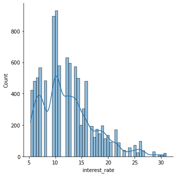

```python
sns.displot(df['interest_rate'], kde='true');
```

The graph is skewed to the right. Since the graph is skewed, we should use a robust measure of the center . The median is 11.98.

## Find correlation between numerical attributes and interest_rate and among numerical attributes with each other

Get the corr_matrix.

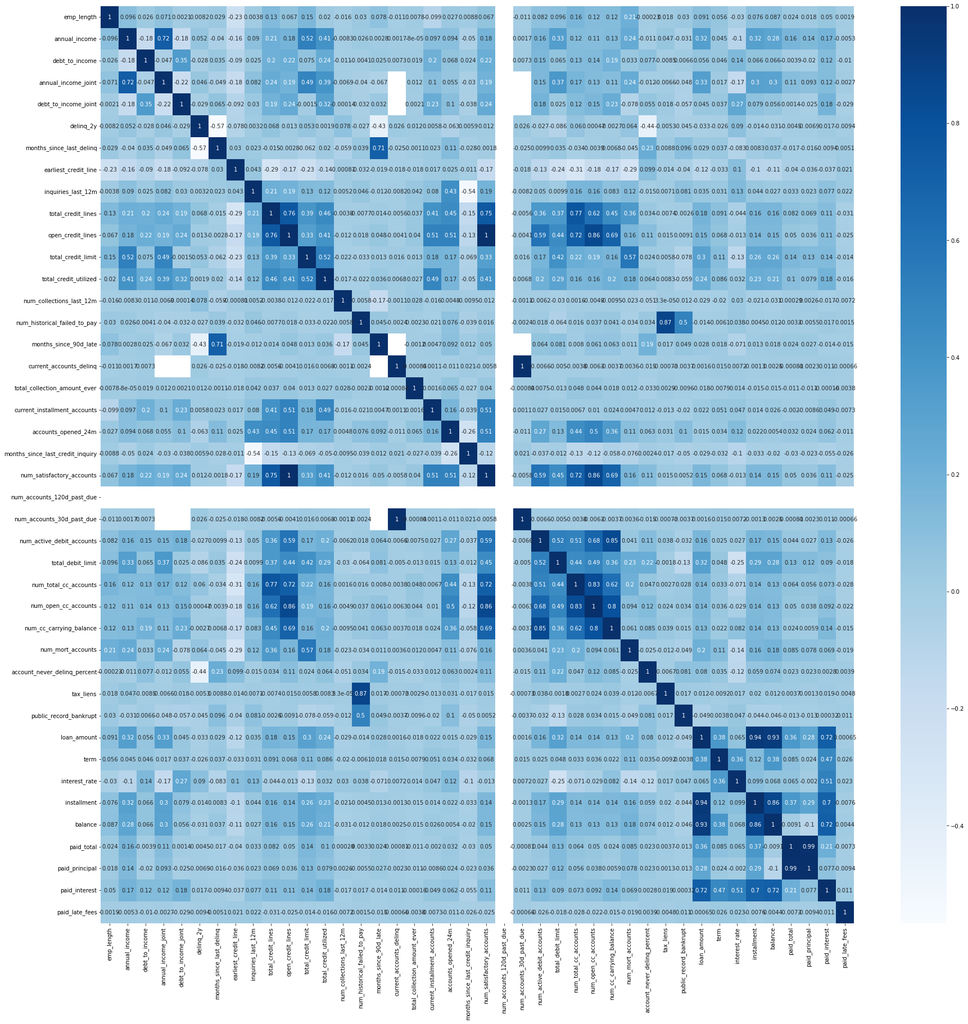

```python
corr_matrix = df.corr()
corr_matrix

plt.figure(figsize = (30,30))
sns.heatmap(corr_matrix, annot=True, cmap='Blues')
```

We focus on the top right half of the heatmap.The open_credit_lines and num_satisfactory are perfectly correlated. We might have to combine the attributes that are highly correlated. They might be attributes that are measuring the same thing from a different angle. An example is loan amount and installments are correlated, which makes sense because the more you own, the more you have to pay back. Another example is paid_total and paid_principle. If you paid a lot, you are paying down the principle and not the interest.

```python
corr_matrix ["interest_rate"].sort_values(ascending=False)
```

```
interest_rate                       1.000000
paid_interest                       0.514508
term                                0.358664
debt_to_income_joint                0.266417
debt_to_income                      0.141653
inquiries_last_12m                  0.131193
accounts_opened_24m                 0.120657
earliest_credit_line                0.103635
installment                         0.098811
delinq_2y                           0.090456
num_cc_carrying_balance             0.081741
balance                             0.067570
paid_total                          0.065339
loan_amount                         0.064527
public_record_bankrupt              0.047477
current_installment_accounts        0.047131
num_historical_failed_to_pay        0.037563
total_credit_utilized               0.031527
num_collections_last_12m            0.029901
num_active_debit_accounts           0.026800
paid_late_fees                      0.023110
tax_liens                           0.016547
total_collection_amount_ever        0.013532
current_accounts_delinq             0.007184
num_accounts_30d_past_due           0.007184
paid_principal                     -0.001953
open_credit_lines                  -0.012773
num_satisfactory_accounts          -0.013330
num_open_cc_accounts               -0.028891
emp_length                         -0.029621
total_credit_lines                 -0.044435
num_total_cc_accounts              -0.071238
months_since_90d_late              -0.071466
months_since_last_delinq           -0.082930
annual_income                      -0.099584
months_since_last_credit_inquiry   -0.100945
account_never_delinq_percent       -0.124702
total_credit_limit                 -0.130497
num_mort_accounts                  -0.138351
annual_income_joint                -0.165327
total_debit_limit                  -0.254225
num_accounts_120d_past_due               NaN
Name: interest_rate, dtype: float64
```

Which numerical have positive/negative assoication with "interest rate"?

Positive- Paid_interest, term, debt_to_income_joint, debt_to_income

Negative- total_debit_limit, annual_income_joint,num_mort_account, total_credit_limit, account_never_delinq_percent, months_since_last_inquiry

Then plot the attributes with highest/lowest correlation to see the type of relationship with "interest rate" and each other- linear

The attribute "term" consist of discrete values 36 and 60- so we don't include that in scatterplot

```python
df["term"]
```

```
0       60
1       36
2       36
3       36
4       36
        ..
9995    36
9996    36
9997    36
9998    36
9999    36
Name: term, Length: 10000, dtype: int64
```

```
array([[<AxesSubplot:xlabel='interest_rate', ylabel='interest_rate'>,
        <AxesSubplot:xlabel='paid_interest', ylabel='interest_rate'>,
        <AxesSubplot:xlabel='debt_to_income_joint', ylabel='interest_rate'>,
        <AxesSubplot:xlabel='annual_income_joint', ylabel='interest_rate'>,
        <AxesSubplot:xlabel='total_debit_limit', ylabel='interest_rate'>],
       [<AxesSubplot:xlabel='interest_rate', ylabel='paid_interest'>,
        <AxesSubplot:xlabel='paid_interest', ylabel='paid_interest'>,
        <AxesSubplot:xlabel='debt_to_income_joint', ylabel='paid_interest'>,
        <AxesSubplot:xlabel='annual_income_joint', ylabel='paid_interest'>,
        <AxesSubplot:xlabel='total_debit_limit', ylabel='paid_interest'>],
       [<AxesSubplot:xlabel='interest_rate', ylabel='debt_to_income_joint'>,
        <AxesSubplot:xlabel='paid_interest', ylabel='debt_to_income_joint'>,
        <AxesSubplot:xlabel='debt_to_income_joint', ylabel='debt_to_income_joint'>,
        <AxesSubplot:xlabel='annual_income_joint', ylabel='debt_to_income_joint'>,
        <AxesSubplot:xlabel='total_debit_limit', ylabel='debt_to_income_joint'>],
       [<AxesSubplot:xlabel='interest_rate', ylabel='annual_income_joint'>,
        <AxesSubplot:xlabel='paid_interest', ylabel='annual_income_joint'>,
        <AxesSubplot:xlabel='debt_to_income_joint', ylabel='annual_income_joint'>,
        <AxesSubplot:xlabel='annual_income_joint', ylabel='annual_income_joint'>,
        <AxesSubplot:xlabel='total_debit_limit', ylabel='annual_income_joint'>],
       [<AxesSubplot:xlabel='interest_rate', ylabel='total_debit_limit'>,
        <AxesSubplot:xlabel='paid_interest', ylabel='total_debit_limit'>,
        <AxesSubplot:xlabel='debt_to_income_joint', ylabel='total_debit_limit'>,
        <AxesSubplot:xlabel='annual_income_joint', ylabel='total_debit_limit'>,
        <AxesSubplot:xlabel='total_debit_limit', ylabel='total_debit_limit'>]],
      dtype=object)
```

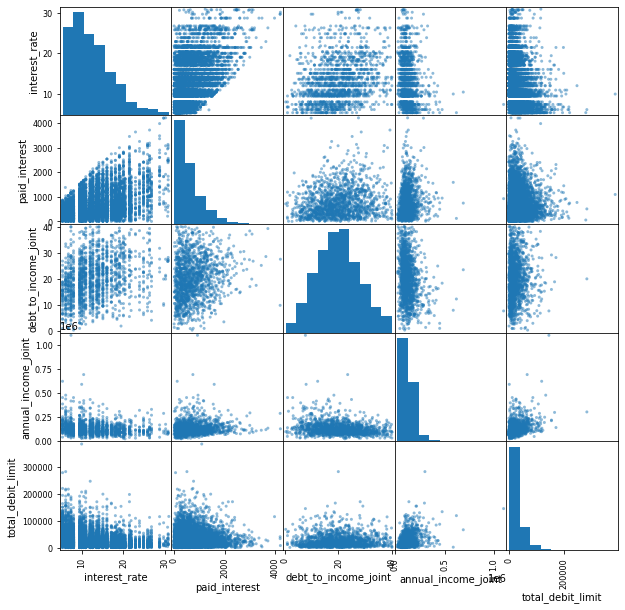

```python
from pandas.plotting import scatter_matrix

attributes = ["interest_rate", "paid_interest", "debt_to_income_joint", "annual_income_joint","total_debit_limit"]

scatter_matrix(df[attributes], figsize=(10, 10))
```

We focus on the left most column.

The scatterplots shows that the paid_interest becomes more disperse as the interest rate increases- more risky. However, there seems to be a line like a cutoff.

The debt_to_income shows high variation but there is a positive correlation.

For annual_income_joint and total_income_joint, as interest rates increases those attributes become less disperse and concentrate to lower annual income and lower debit_limit.

Conclusion: Higher interest rates- less dispersion. Lower_income and lower_debit_limit means more risky- higher interest rates. Higher paid_interest and debt_to_income more risky- highest interest rate. These factors make sense.

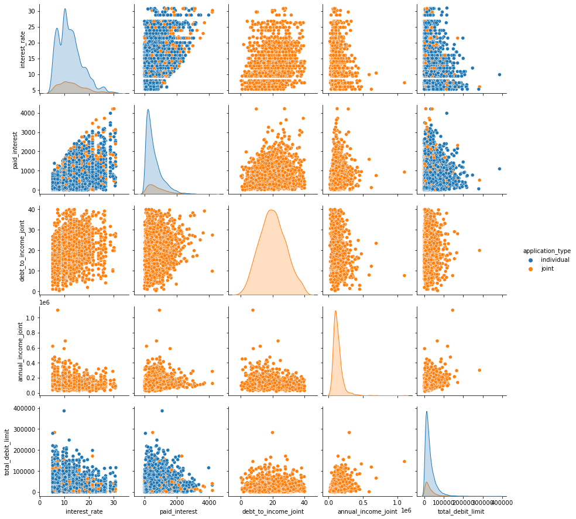

```python
from pandas.plotting import scatter_matrix

attributes = ["interest_rate", "paid_interest", "debt_to_income_joint", "annual_income_joint","total_debit_limit", 'application_type']

sns.pairplot(df[attributes], hue='application_type')
```

When we add the application type to the equation. For paid_interest and total debt limit, the application type have no difference in the interest rate.

## Categorical Variables

Boxplots tell us the 25%, 50%, 75% quantile. The whisker measures the spread.

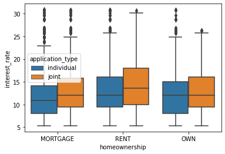

```python
sns.boxplot(x='homeownership', y='interest_rate', data= df, hue='application_type')
```

The type of homeownership have no impact on the interest_rate.

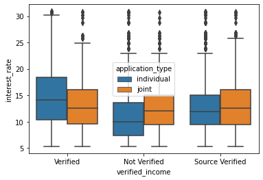

```python
sns.boxplot(x='verified_income', y='interest_rate', data= df, hue='application_type')
```

Maybe verification of income does not have large impact on interest_rate. All the median interest_rate is from 10-15, the variance is also large, so the difference in median is not significant.

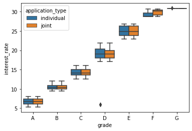

```python
sns.boxplot(x='grade', y='interest_rate', data= df, hue='application_type' ,order=['A', 'B', 'C', 'D', 'E', 'F', 'G'])
```

The grade associated with the loan affects the interest rate- lower lexicographical order the lower the interest rate. There is no difference between the different application types. There is also an outlier for grade D.

## Cleaning Data

I will drop the rows with na. I can also fill the na with values but that would require business knowledge

```python
df = df.dropna(subset=["emp_title"])
df.info()
```

```
<class 'pandas.core.frame.DataFrame'>
Int64Index: 9167 entries, 0 to 9999
Data columns (total 55 columns):
 #   Column                            Non-Null Count  Dtype
---  ------                            --------------  -----
 0   emp_title                         9167 non-null   object
 1   emp_length                        9167 non-null   float64
 2   state                             9167 non-null   object
 3   homeownership                     9167 non-null   object
 4   annual_income                     9167 non-null   float64
 5   verified_income                   9167 non-null   object
 6   debt_to_income                    9166 non-null   float64
 7   annual_income_joint               1292 non-null   float64
 8   verification_income_joint         1258 non-null   object
 9   debt_to_income_joint              1292 non-null   float64
```

[output cut: 47 more lines]

The months_since_last_delinq, months_since_90d_late, months_since_last_credit_inquiry, num_accounts_120d_past_due contains a lot of na values. I am not sure if na stands for 0. I will remove those colums just in case.

The debt_to_income has one null so I will just delete that row.

I won't remove annual_income_joint, verification_income_joint, debt_to_income_joint because na means individual. The # of non-null are not same across the rows. Just in case, I will delete the na rows whose application type is not individual.

```python
df = df[~(df['verification_income_joint'].isna() & (df.application_type =='joint'))]
df = df.dropna(subset=["debt_to_income"])
df = df.drop(['months_since_last_delinq', 'months_since_90d_late', 'num_accounts_120d_past_due', 'months_since_last_credit_inquiry'], axis=1)
```

I will separate the loans that are joint and those that are individual. I think it is a good idea to train a different model for each application type since the populations are not similar otherwise.

```python
df_indiv = df[(df.application_type =='individual')]
```

```python
df_indiv = df_indiv.drop(['annual_income_joint','verification_income_joint','debt_to_income_joint'],axis=1)
```

```python
df_joint = df[(df.application_type =='joint')]
```

Use an encoder to convert the labels into numerical form so it is machine readable

```python
from sklearn.preprocessing import LabelEncoder
encoder = LabelEncoder()
df_indiv = df_indiv.apply(encoder.fit_transform)
df_indiv
```

|  | emp_title | emp_length | state | homeownership | annual_income | verified_income | debt_to_income | delinq_2y | earliest_credit_line | inquiries_last_12m | ... | sub_grade | issue_month | loan_status | initial_listing_status | disbursement_method | balance | paid_total | paid_principal | paid_interest | paid_late_fees |
| --- | --- | --- | --- | --- | --- | --- | --- | --- | --- | --- | --- | --- | --- | --- | --- | --- | --- | --- | --- | --- | --- |
| 0 | 1573 | 3 | 30 | 0 | 726 | 2 | 1548 | 0 | 36 | 6 | ... | 12 | 2 | 1 | 1 | 0 | 4100 | 3671 | 2504 | 4939 | 0 |
| 1 | 4158 | 10 | 11 | 2 | 212 | 0 | 331 | 0 | 31 | 1 | ... | 10 | 0 | 1 | 1 | 0 | 728 | 537 | 540 | 996 | 0 |
| 2 | 184 | 3 | 47 | 2 | 212 | 1 | 1845 | 0 | 41 | 4 | ... | 15 | 0 | 1 | 0 | 0 | 150 | 178 | 136 | 651 | 0 |
| 3 | 920 | 1 | 37 | 2 | 91 | 0 | 789 | 0 | 42 | 0 | ... | 2 | 1 | 1 | 1 | 0 | 3269 | 4983 | 4298 | 3559 | 0 |
| 7 | 2696 | 10 | 3 | 0 | 835 | 1 | 1371 | 1 | 40 | 1 | ... | 9 | 1 | 1 | 1 | 0 | 3294 | 3269 | 2524 | 4336 | 0 |
| ... | ... | ... | ... | ... | ... | ... | ... | ... | ... | ... | ... | ... | ... | ... | ... | ... | ... | ... | ... | ... | ... |
| 9994 | 946 | 1 | 46 | 2 | 212 | 0 | 970 | 0 | 43 | 0 | ... | 7 | 2 | 1 | 0 | 0 | 155 | 4810 | 4358 | 746 | 0 |
| 9995 | 2505 | 10 | 42 | 2 | 827 | 1 | 1952 | 0 | 43 | 5 | ... | 3 | 1 | 1 | 1 | 0 | 3558 | 4733 | 4173 | 3512 | 0 |
| 9996 | 1060 | 8 | 37 | 0 | 871 | 2 | 2768 | 4 | 29 | 1 | ... | 17 | 0 | 1 | 1 | 0 | 1635 | 2719 | 2167 | 3702 | 0 |
| 9998 | 2131 | 1 | 47 | 0 | 650 | 1 | 962 | 0 | 34 | 1 | ... | 0 | 0 | 1 | 1 | 0 | 3549 | 4666 | 4204 | 2687 | 0 |
| 9999 | 2451 | 3 | 6 | 2 | 515 | 0 | 1815 | 0 | 40 | 0 | ... | 8 | 0 | 1 | 1 | 0 | 2164 | 3093 | 3000 | 2918 | 0 |

7875 rows × 48 columns

```python
from sklearn.preprocessing import LabelEncoder
encoder = LabelEncoder()
df_joint = df_joint.apply(encoder.fit_transform)
df_joint
```

|  | emp_title | emp_length | state | homeownership | annual_income | verified_income | debt_to_income | annual_income_joint | verification_income_joint | debt_to_income_joint | ... | sub_grade | issue_month | loan_status | initial_listing_status | disbursement_method | balance | paid_total | paid_principal | paid_interest | paid_late_fees |
| --- | --- | --- | --- | --- | --- | --- | --- | --- | --- | --- | --- | --- | --- | --- | --- | --- | --- | --- | --- | --- | --- |
| 4 | 684 | 10 | 4 | 2 | 78 | 2 | 1052 | 32 | 2 | 1017 | ... | 12 | 2 | 1 | 1 | 0 | 673 | 718 | 769 | 704 | 0 |
| 6 | 347 | 10 | 21 | 0 | 78 | 1 | 498 | 341 | 0 | 231 | ... | 11 | 1 | 1 | 1 | 0 | 705 | 842 | 721 | 988 | 0 |
| 21 | 848 | 1 | 32 | 0 | 102 | 1 | 708 | 166 | 1 | 352 | ... | 9 | 2 | 1 | 1 | 0 | 236 | 221 | 302 | 260 | 0 |
| 32 | 785 | 9 | 2 | 0 | 135 | 2 | 806 | 186 | 2 | 571 | ... | 17 | 0 | 1 | 1 | 0 | 580 | 591 | 369 | 921 | 0 |
| 37 | 772 | 10 | 30 | 0 | 203 | 2 | 331 | 199 | 2 | 235 | ... | 13 | 2 | 3 | 1 | 0 | 742 | 271 | 190 | 529 | 0 |
| ... | ... | ... | ... | ... | ... | ... | ... | ... | ... | ... | ... | ... | ... | ... | ... | ... | ... | ... | ... | ... | ... |
| 9981 | 607 | 7 | 16 | 0 | 185 | 0 | 801 | 408 | 0 | 693 | ... | 6 | 1 | 3 | 1 | 0 | 832 | 1031 | 1005 | 839 | 0 |
| 9984 | 737 | 7 | 6 | 0 | 131 | 1 | 796 | 178 | 1 | 857 | ... | 19 | 1 | 3 | 1 | 0 | 910 | 956 | 621 | 1157 | 0 |
| 9987 | 181 | 6 | 42 | 0 | 160 | 1 | 460 | 179 | 0 | 923 | ... | 5 | 2 | 1 | 1 | 0 | 476 | 222 | 257 | 328 | 0 |
| 9991 | 785 | 10 | 18 | 0 | 217 | 1 | 630 | 425 | 1 | 683 | ... | 9 | 1 | 1 | 1 | 0 | 971 | 1026 | 928 | 1096 | 0 |
| 9997 | 812 | 10 | 6 | 0 | 192 | 2 | 952 | 204 | 1 | 891 | ... | 21 | 0 | 1 | 0 | 0 | 841 | 1095 | 959 | 1172 | 0 |

1257 rows × 51 columns

```python
df_indiv.drop('emp_title', axis=1)
```

|  | emp_length | state | homeownership | annual_income | verified_income | debt_to_income | delinq_2y | earliest_credit_line | inquiries_last_12m | total_credit_lines | ... | sub_grade | issue_month | loan_status | initial_listing_status | disbursement_method | balance | paid_total | paid_principal | paid_interest | paid_late_fees |
| --- | --- | --- | --- | --- | --- | --- | --- | --- | --- | --- | --- | --- | --- | --- | --- | --- | --- | --- | --- | --- | --- |
| 0 | 3 | 30 | 0 | 726 | 2 | 1548 | 0 | 36 | 6 | 26 | ... | 12 | 2 | 1 | 1 | 0 | 4100 | 3671 | 2504 | 4939 | 0 |
| 1 | 10 | 11 | 2 | 212 | 0 | 331 | 0 | 31 | 1 | 28 | ... | 10 | 0 | 1 | 1 | 0 | 728 | 537 | 540 | 996 | 0 |
| 2 | 3 | 47 | 2 | 212 | 1 | 1845 | 0 | 41 | 4 | 29 | ... | 15 | 0 | 1 | 0 | 0 | 150 | 178 | 136 | 651 | 0 |
| 3 | 1 | 37 | 2 | 91 | 0 | 789 | 0 | 42 | 0 | 2 | ... | 2 | 1 | 1 | 1 | 0 | 3269 | 4983 | 4298 | 3559 | 0 |
| 7 | 10 | 3 | 0 | 835 | 1 | 1371 | 1 | 40 | 1 | 28 | ... | 9 | 1 | 1 | 1 | 0 | 3294 | 3269 | 2524 | 4336 | 0 |
| ... | ... | ... | ... | ... | ... | ... | ... | ... | ... | ... | ... | ... | ... | ... | ... | ... | ... | ... | ... | ... | ... |
| 9994 | 1 | 46 | 2 | 212 | 0 | 970 | 0 | 43 | 0 | 16 | ... | 7 | 2 | 1 | 0 | 0 | 155 | 4810 | 4358 | 746 | 0 |
| 9995 | 10 | 42 | 2 | 827 | 1 | 1952 | 0 | 43 | 5 | 42 | ... | 3 | 1 | 1 | 1 | 0 | 3558 | 4733 | 4173 | 3512 | 0 |
| 9996 | 8 | 37 | 0 | 871 | 2 | 2768 | 4 | 29 | 1 | 26 | ... | 17 | 0 | 1 | 1 | 0 | 1635 | 2719 | 2167 | 3702 | 0 |
| 9998 | 1 | 47 | 0 | 650 | 1 | 962 | 0 | 34 | 1 | 36 | ... | 0 | 0 | 1 | 1 | 0 | 3549 | 4666 | 4204 | 2687 | 0 |
| 9999 | 3 | 6 | 2 | 515 | 0 | 1815 | 0 | 40 | 0 | 13 | ... | 8 | 0 | 1 | 1 | 0 | 2164 | 3093 | 3000 | 2918 | 0 |

7875 rows × 47 columns

Splitting the data into train feature, train level, test feature, test label

```python
X = df_indiv.drop("interest_rate", axis=1)
y = df_indiv["interest_rate"].copy()
```

```python
X_train, X_test, y_train, y_test = train_test_split (X, y, test_size=.2, random_state=42)

X_train.shape , X_test.shape, y_train.shape , y_test.shape
```

```
((6300, 47), (1575, 47), (6300,), (1575,))
```

## Model

We need regression model to predict data. Supervised learning algorithm.

We will use linear regression and logistic regression

```python
# Logistic Regression
from sklearn.linear_model import LogisticRegression

logreg = LogisticRegression()
logreg.fit(X_train, y_train)
y_pred_log = logreg.predict(X_test)
```

```python
# Linear Regression

from sklearn.linear_model import LinearRegression

linreg = LinearRegression()
linreg.fit(X_train, y_train)
y_pred_lin = linreg.predict(X_test)
```

```python
# Log Regression

from sklearn.metrics import mean_squared_error
from sklearn.metrics import mean_absolute_error
import math

MSE_log = mean_squared_error(y_test, y_pred_log)
RMSE_log = math.sqrt(mean_squared_error(y_test, y_pred_log))
MAE_log = mean_absolute_error(y_test, y_pred_log)
```

```python
# Linear Regression

MSE_lin = mean_squared_error(y_test, y_pred_lin)
RMSE_lin = math.sqrt(mean_squared_error(y_test, y_pred_lin))
MAE_lin = mean_absolute_error(y_test, y_pred_lin)
```

## Conclusion:

The MSE, RMSE, MAE is higher for logistic regression. This might be because the model iterations limit was reached and it did not fully converge to a solution. The model is able to generalize the data well. Next time, I will try more models and see if I can lower the error. Next time, I would also create a model for the joint application type.

```python
models = pd.DataFrame({
    'Model': ['Linear Regression', 'Logistic Regression'],
    'MSE': [MSE_lin, MSE_log],
    'RMSE': [RMSE_lin, RMSE_log],
    'MAE': [MAE_lin, MAE_log]})
models
```

|  | Model | MSE | RMSE | MAE |
| --- | --- | --- | --- | --- |
| 0 | Linear Regression | 0.863328 | 0.929155 | 0.40191 |
| 1 | Logistic Regression | 40.624127 | 6.373706 | 4.36381 |